# Midterm project

10/21/2019

## The Question:

Is there any correlation between GDP per Capita and prevalence of HIV in the 15–49 age bracket? And if yes, how strong is that correlation?

How about the correlation between GDP per Capita and prevalence of HIV in female?

## The Data

In this data analysis, I use the data available on World Bank webpage.  
Briefly description of each data set:

**GDP/capita** : GDP per capita is gross domestic product divided by midyear population.

**Prevalence of HIV among people aged 15–49 (%)**: Prevalence of HIV refers to the percentage of people ages 15-49 who are infected with HIV.

**Prevalence of HIV, female among people aged 15-24(%)**: Prevalence of HIV, female is the percentage of females who are infected with HIV. Youth rates are as a percentage of the relevant age group.

## Combing dataframe & data cleaning

We remove all entries that are aggregated regional values and then we rename the indicators.Then we combine the three dataframes to allow us to compare GDP per capita and HIV prevalence and HIV prevalence, female.

## Summary of missing data

Datasets often feature missing data.So we need to take a look at the percentage of missing data in the combined dataframe.

About 24.3% of the GDP per Capita column in the combined dataframe have missing data.

This is quite substantial and is most likely due the fact that consistent measurements of GDP are costly and have only started in the last few decades according to the World Bank webpage (It was found in 1945 after WWII).

And we have an at 68.5% for HIV Prevalence missing data and 69.1% for HIV Prevalence of female in the combined dataframe.

## Distrubtion of each data set

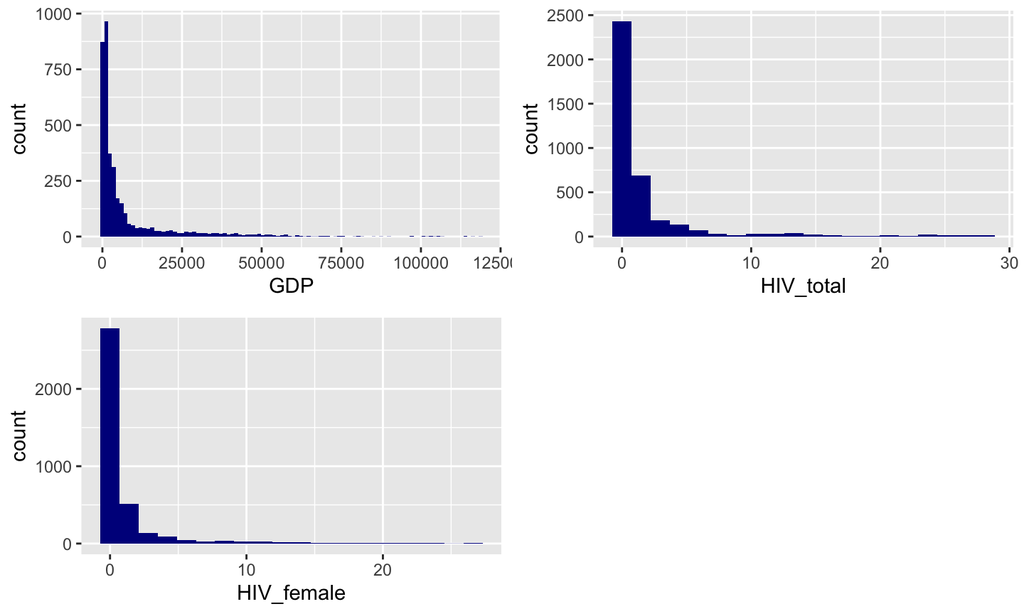

## Summary of each data set

```
##      Min.   1st Qu.    Median      Mean   3rd Qu.      Max.
##     95.19    663.73   1943.92   7749.73   6651.29 118823.65
```

```
##    Min. 1st Qu.  Median    Mean 3rd Qu.    Max.
##   0.100   0.100   0.300   1.977   1.500  28.200
```

```
##    Min. 1st Qu.  Median    Mean 3rd Qu.    Max.
##   0.100   0.100   0.100   1.314   0.900  26.700
```

## Big picture of the data

| year | HIV_female | HIV_total | GDP |
| --- | --- | --- | --- |
| 1990 | 1.0066 | 0.9426 | 4115.235 |
| 1991 | 1.2132 | 1.1248 | 4240.756 |
| 1992 | 1.4240 | 1.3025 | 4433.751 |
| 1993 | 1.6016 | 1.4512 | 4241.299 |
| 1994 | 1.7750 | 1.5863 | 4485.679 |
| 1995 | 1.8608 | 1.6369 | 5089.958 |
| 1996 | 1.9962 | 1.7192 | 5242.818 |
| 1997 | 2.1085 | 1.7662 | 5176.325 |

## Scatter plots

First, we look at the overall data set and generate a scatter plot of GDP per Capita and HIV Prevalence in for the 136 countries listed in our dataset from 1990 to 2018.

## Scatter plot of GDP per Capita

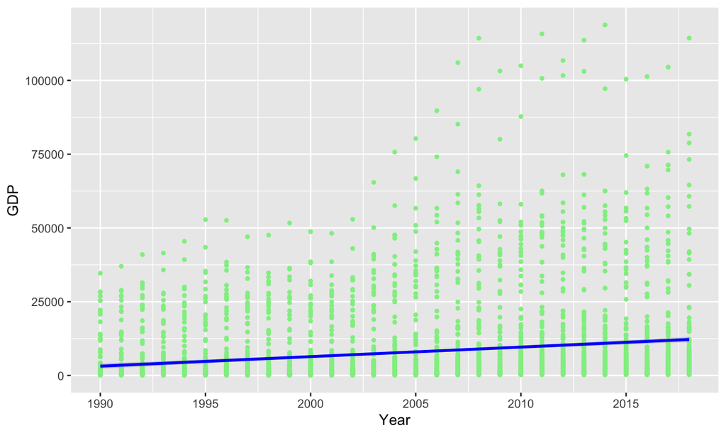

## Scatter plot of Prevalence of HIV total

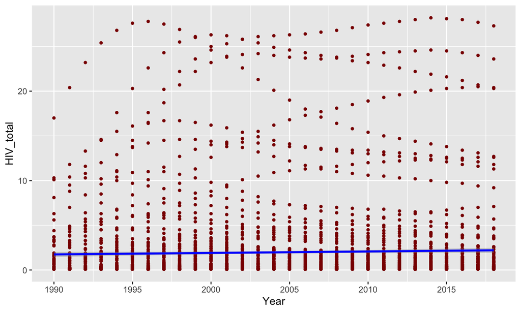

## Scatter plot of Prevalence of HIV female

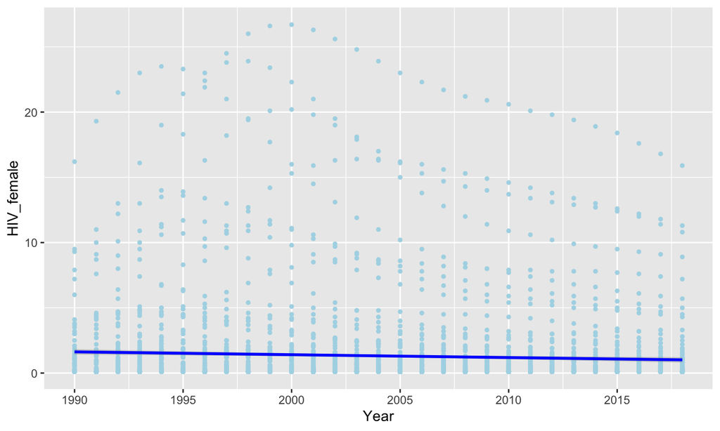

## Correlation and Linear Regression

Let’s take a closer look by creating a plot with a square root scale applied to the x-axis to further emphasise countries with lower GDP per capita. We’ll also use the R function geom_smooth() to perform a simple linear regression to better visualise the relationship between the two variables.

## HIV Prevalance vs. GDP per Capita.

[figure not shown]

## Square root scale of GDP

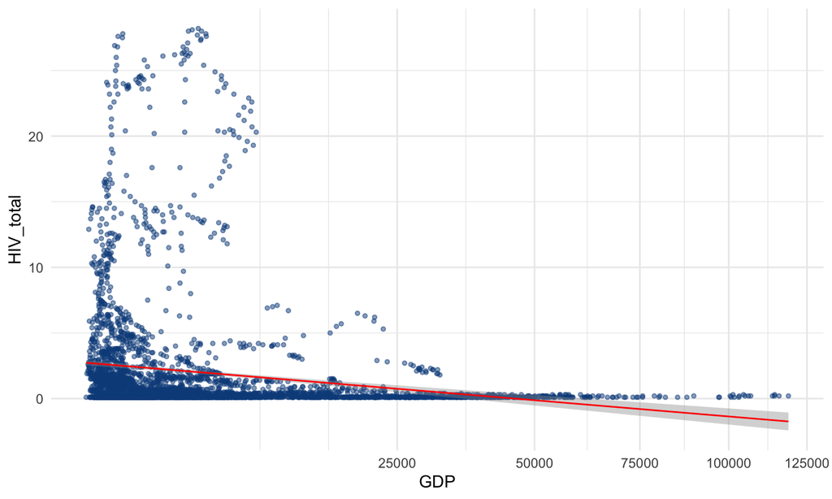

## HIV Prevalance female vs. GDP per Capita.

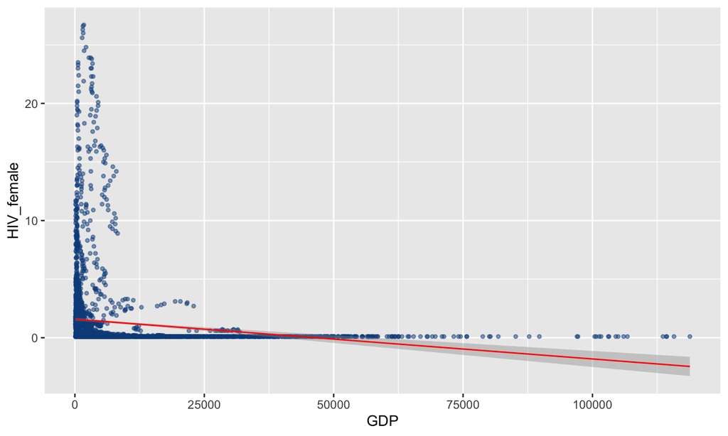

## Square root scale of GDP

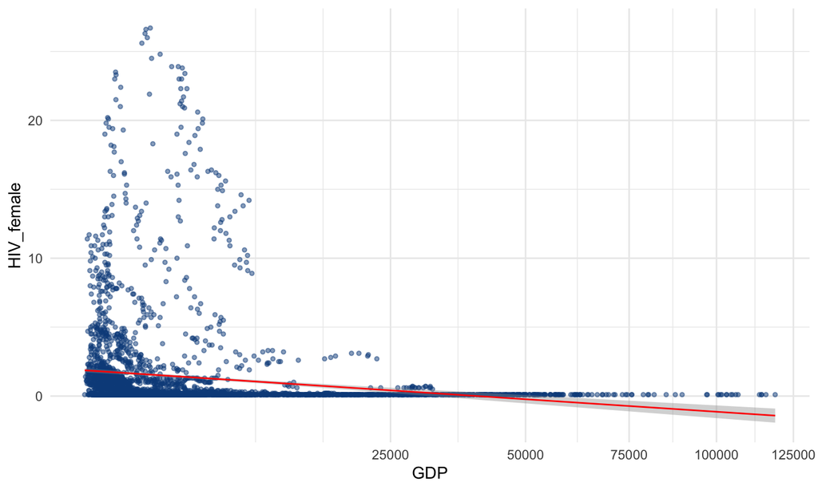

## Explore more of the data

Futhermore, I want to select top ten HIV prevalance in total and in female countries for the most rencently year(2018) of the data set. So I made a table to arrange the data first, then I compared the GDP of those ten countries in 2018 with their HIV to see if their is any correlation.

## Select the top ten HIV Prevalance countries (2018)

| country | HIV_total | HIV_female |
| --- | --- | --- |
| Eswatini | 27.3 | 15.9 |
| Lesotho | 23.6 | 10.8 |
| South Africa | 20.4 | 11.3 |
| Botswana | 20.3 | 8.9 |
| Zimbabwe | 12.7 | 5.7 |
| Mozambique | 12.6 | 7.2 |
| Namibia | 11.8 | 4.5 |
| Zambia | 11.3 | 5.0 |
| Malawi | 9.2 | 4.3 |
| Equatorial Guinea | 7.1 | 3.3 |

## Select the top ten HIV Prevalance of female countries (2018)

| country | HIV_total | HIV_female |
| --- | --- | --- |
| Eswatini | 27.3 | 15.9 |
| South Africa | 20.4 | 11.3 |
| Lesotho | 23.6 | 10.8 |
| Botswana | 20.3 | 8.9 |
| Mozambique | 12.6 | 7.2 |
| Zimbabwe | 12.7 | 5.7 |
| Zambia | 11.3 | 5.0 |
| Namibia | 11.8 | 4.5 |
| Malawi | 9.2 | 4.3 |
| Equatorial Guinea | 7.1 | 3.3 |

## HIV Prevalance in total and GDP per capita by Country (2018)

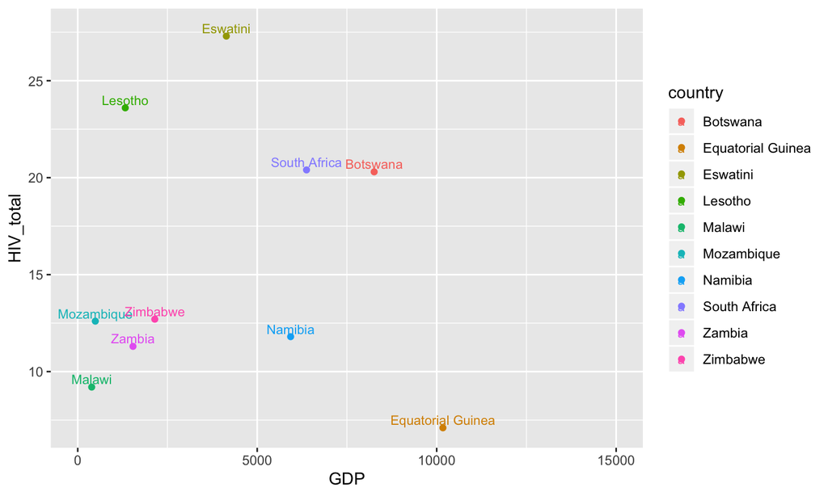

## HIV Prevalance in female and GDP per capita by Country (2018)

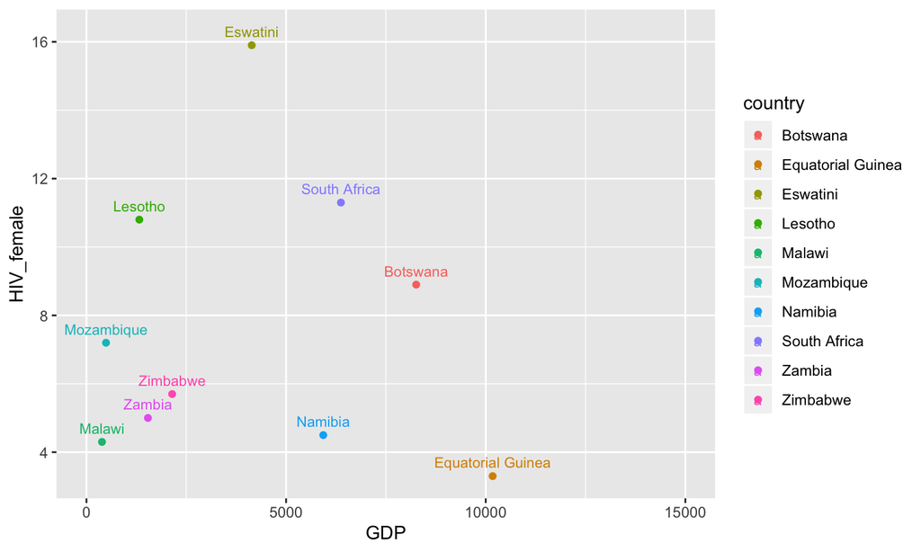